# OkCupid Project DAT402

Giovanni Aratico

2023-04-03

## PROJECT 1: Predict Male / Female profiles on OkCupid

What do we want to predict and why? * Our goal is to predict the gender of individuals based on the language used in their profile prompts. By analyzing these profiles and making accurate predictions, we can improve matchmaking algorithms and tailor marketing strategies to better reach each gender.

```r
set.seed(196)
df = read.csv("data/okcupid_profiles.csv")
```

## Data Cleaning and Feature Engineering

To prepare our dataset for categorical analysis, we convert several columns into factors. Additionally, we extract the year from the “last online” column to assess the duration of user inactivity. Notably, all profiles were last online in either 2011 or 2012. This finding suggests that the data was either collected during that period or that all profiles have since become inactive. Furthermore, we observe that 91 out of 59,946 profile locations did not contain the keyword “California.” This suggests that the dataset only includes users from California, and that these 91 observations likely belong to out-of-state visitors or data errors.

```r
set.seed(196)
df = group_locations_by_region(df)
df_clean = data_cleaning(df)
df_clean = feature_engineering(df_clean)
df_clean = df_clean[sample(nrow(df_clean)),]
```

## EDA Plots

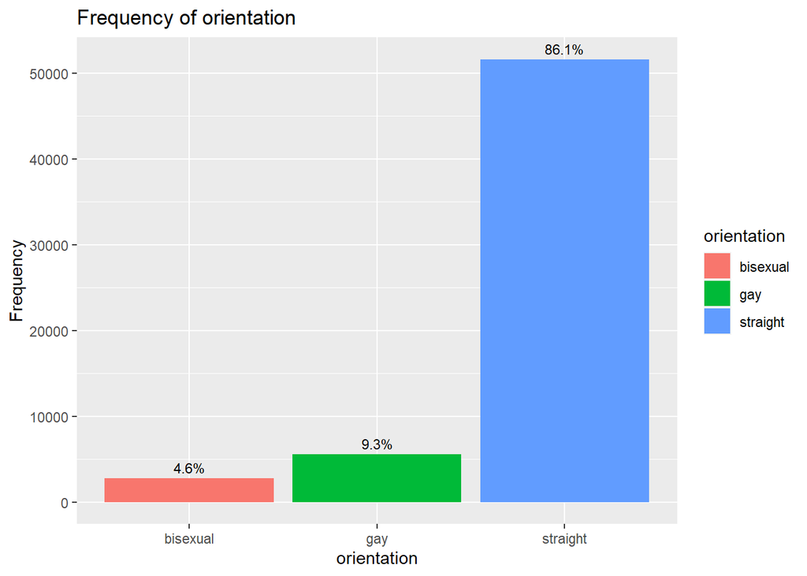

```r
# Plot histogram of orientation
plot_frequency(df, orientation)
```

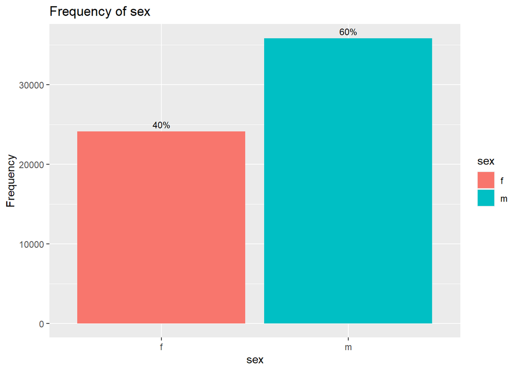

```r
# Plot histogram of sex
plot_frequency(df, sex)
```

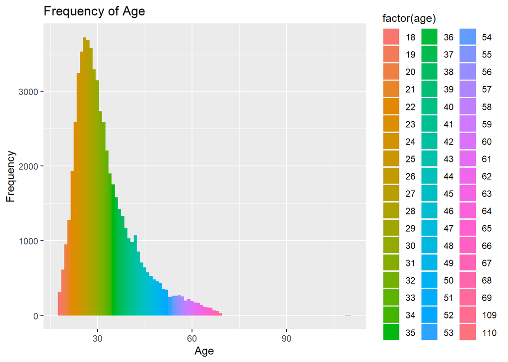

```r
# Plot histogram of all ages
plot_age_histogram(df)
```

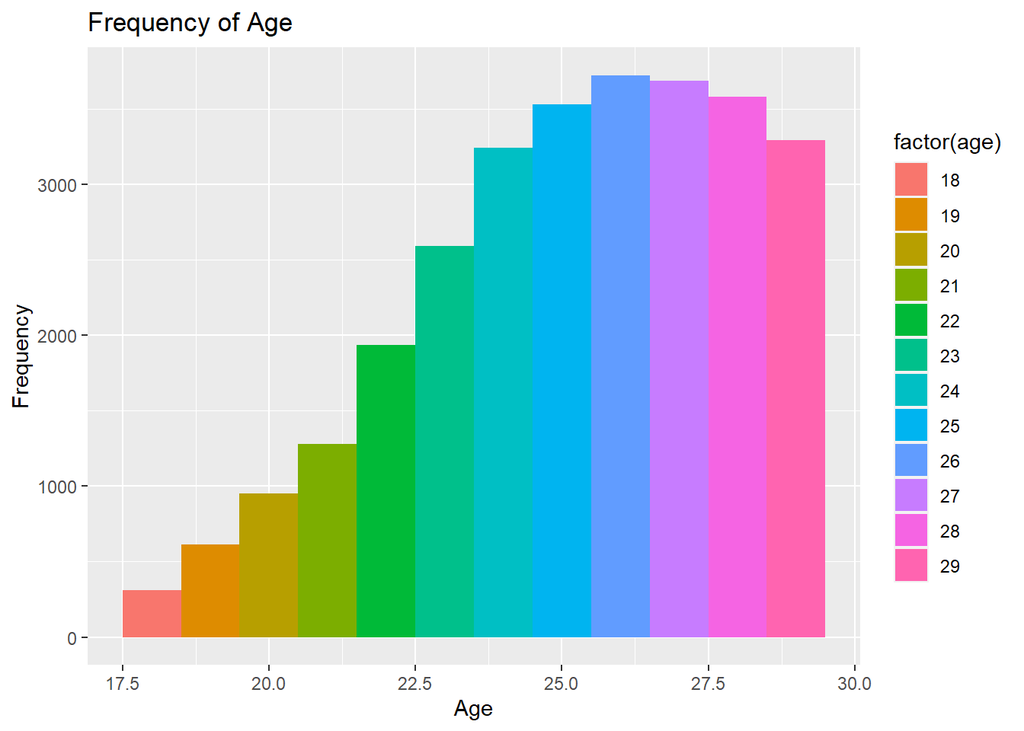

```r
# Plot histogram of ages 18-29
plot_age_histogram(df, age_range = c(18, 29))
```

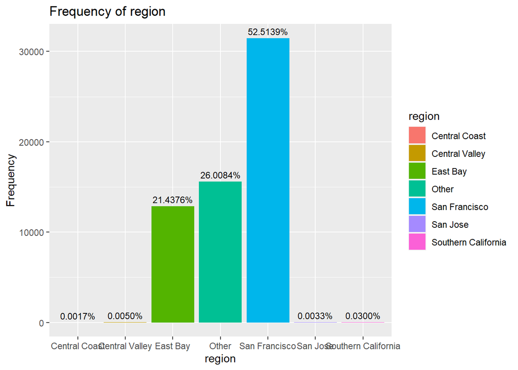

```r
# Plot histogram of region location
plot_frequency(df, region)
```

## Train / Test Split

We randomly sample 5% of the cleaned data to create a smaller dataset for training and testing our models. Additionally, we used an 80-20 split to partition the data into training and test sets, respectively. This allows us to evaluate the performance of our models on new data while minimizing overfitting to the training set.

```r
set.seed(196)  # Set seed for reproducibility
# Create a stratified sample of 5% from the "sex_binary" column
stratified_sample = sample.split(df_clean$sex_binary, SplitRatio = 0.05)

# Split data into 80% training and 20% testing
split = sample.split(df_clean$sex_binary, SplitRatio = 0.8)
# Subset the clean data with the stratified sample
stratified_data = df_clean[stratified_sample, ]

# Split the stratified data into training and testing sets with an 80/20 ratio
split = sample.split(stratified_data$sex_binary, SplitRatio = 0.8)

# Create training and testing data frames
train_df = stratified_data[split, ]
test_df = stratified_data[!split, ]
```